# 7 Talousrikokset

*Anna Raeste & Ilari Kolttola*

## 7.1 Tiivistelmä

- Vuonna 2024 viranomaisten tietoon tuli 3 331 vero-, kirjanpito- ja velallisen rikosta, mikä oli 3 prosenttia enemmän kuin edellisenä vuonna. Mainittujen rikosten määrä näyttää jatkavan edellisten vuosien nousujohteisella suunnalla ja vuosien 2020 ja 2021 laskun jälkeen nousseen jälleen lähelle vuoden 2019 huippulukuja.
- Yleisimpiä talousrikoksia olivat aiempien vuosien kaltaisesti verorikokset. Vuonna 2024 verorikosten määrä kuitenkin jopa laski edeltävistä vuosista, kirjanpito- ja velallisrikosten saavuttaessa puolestaan kymmenvuotiskauden korkeimmat luvut. Vuonna 2024 törkeiden veropetosten osuus kaikista verorikoksista oli 57 prosenttia.
- Poliisin kirjaamat arvopaperimarkkinarikokset ovat vuositasolla harvinaisia. Kymmenen vuoden aikana epäilyjä on ollut keskimäärin seitsemän kappaletta vuosittain. Vuosina 2015–2024 Finanssivalvonta käsitteli kaikkiaan 1 379 valvontatapausta. Poliisille tehtiin tutkintapyyntö 65 tapauksesta.
- Rahanpesun selvittelykeskukselle tehtiin vuonna 2024 yhteensä 53 482 ilmoitusta epäilyttävistä liiketoimista. Kyseessä on selkeä lasku edeltävistä kolmesta vuodesta, jolloin erityisesti maksujenvälitystä tarjoavat ilmoitusvelvolliset nostivat ilmoitusmäärät poikkeuksellisen korkealle. Selvittelykeskukseen tehdyt ilmoitukset ovat keskittyneet finanssisektorin ilmoitusvelvollisten tekemiin riskiperustaisiin ilmoituksiin ja poispäin epäilyttävää liiketoimea koskevista ilmoituksista.
- Talousrikoksista epäiltyjen henkilöiden ikärakenne ja sosioekonominen rakenne poikkeaa muista rikostyypeistä. Talousrikoksista epäillyt ovat keskimäärin vanhempia ja heidän sosioekonominen asemansa on jonkin verran korkeampi kuin muista rikoslajeista epäillyillä. Toisaalta myös talousrikoksissa henkilöt, joilla on matala sosioekonominen asema tai jotka ovat pienituloisia, ovat yliedustettuina epäiltyjen joukossa.
- Viranomaisten tietoon tullut talousrikollisuus näyttäisi palanneen 2010-luvun lopun tasolle. On todennäköistä, että ainakin osa ilmi tulleen talousrikollisuuden viime vuosien noususta selittyy valvonnan painopistealueiden muutoksilla.

Tässä luvussa tarkastellaan talousrikoksia, joista keskeisimpinä ovat verorikokset, velallisen rikokset ja kirjanpitorikokset. Muita luvussa käsiteltäviä talousrikoksia ovat arvopaperimarkkinarikokset sekä rahanpesu. Käsittelyn ala ei kata kaikkia talousrikoksia, joita ovat edellä mainittujen lisäksi esimerkiksi julkishallinnon korruptio, osa petosrikoksista, sekä ympäristö- ja työrikokset.[^10] Ajankohtaista tietoa ympäristörikosten yleisyydestä ja piirteistä on saatavilla Suomen kansallisen ympäristörikosseurantaryhmän Ympäristörikoskatsauksesta (Suomen kansallinen ympäristörikosseurantaryhmä 2024). Työrikoksia koskevista tutkimuksista voidaan mainita Työterveyslaitoksen ja Turun yliopiston toteuttama tutkimus (Alvesalo-Kuusi ym. 2017), jossa tarkasteltiin oikeushenkilön rangaistusvastuun toteutumista työturvallisuusrikoksissa.

1. Rikollisuuden kehitys

   *Vero-, kirjanpito- ja velallisen rikokset*

Seuraavassa tarkastelussa ovat vero- (RL 29:1–4), kirjanpito- (RL 30:9–10) ja velallisen rikokset (RL 39:1–6), jotka ovat lukumääräisesti yleisimpiä talousrikoksia. Verorikoksissa kyse on ensisijaisesti rikoksista julkista taloutta vastaan, kun taas kirjanpitorikokset kohdistuvat esimerkiksi osakkaiden ja osakkeenomistajien intresseihin. Velallisen rikoksia koskevilla säännöksillä puolestaan on pyritty suojaamaan velkojien asema ja tasapuolinen kohtelu velallisen maksukyvyttömyystilanteessa. Käytännössä kaikki edellä mainitut rikoslajit liittyvät usein toisiinsa.

Talousrikollisuuden määrällisestä kehityksestä ja rakenteellisista muutoksista on saatavissa tietoja lähinnä viranomaistilastoista. Tilastokeskuksen rikos- ja pakkokeinotilasto sisältää poliisin, Tullin ja Rajavartiolaitoksen tietoon tulleet rikokset. Muita tärkeitä tiedonlähteitä ovat Verohallinnon, Finanssivalvonnan ja Rahanpesun selvittelykeskuksen julkaisemat tilastot ja vuosikertomukset. Mainitut lähteet kertovat viranomaisten tietoon tulleesta rikollisuudesta. Kokonaisrikollisuudesta on talousrikollisuuden osalta saatavissa tietoa lähinnä erillistutkimuksista, joissa aiheena on tavallisesti jokin talousrikollisuuden erityismuoto. Kattavia talousrikollisuutta koskevia kansallisia kyselytutkimuksia ei Suomessa ole toistaiseksi tehty. Yrityksiin kohdistuvaa rikollisuutta, mukaan lukien talousrikokset, on tarkasteltu vuosina 2010 ja 2018 toteutetussa Yritysuhritutkimuksessa (Salmi, Lehti & Keinänen 2011; Saarikkomäki, Lehti & Kivivuori 2019). Kyselyn painopiste ei kuitenkaan ole ollut talousrikollisuudessa. Sekä palkansaajien että elinkeinoelämän etujärjestöjen parissa on tehty joitakin jäsenistöön suunnattuja kyselytutkimuksia, joilla on pyritty selvittämään muun ohessa myös talousrikollisuuden ilmiöiden yleisyyttä toimialakohtaisesti.

Vuonna 2024 viranomaisten tietoon tuli 3 331 vero-, kirjanpito- ja velallisen rikosta, mikä oli 3 prosenttia enemmän kuin edellisenä vuonna. Rikosten kokonaismäärä näyttää täten jatkavan edellisten vuosien nousujohteisella suunnalla ja nousseen hyvin lähelle vuoden 2019 huippua (kuvio 1). Kasvu oli kuitenkin hyvin pientä verrattuna edelliseen vuoteen. Rikosten määrän muutokset ovat johtuneet pitkällä aikavälillä pääasiassa verorikoksista, joiden määrä kaksinkertaistui vuosina 2010–2019 ja on lisääntynyt jälleen viime vuosina vuoden 2021 merkittävän laskun jälkeen. Vuonna 2024 verorikosten määrä kuitenkin jopa laski, kirjanpito- ja velallisrikosten saavuttaessa puolestaan kymmenvuotiskauden korkeimmat luvut. Ilmiö heijastelee todennäköisesti ainakin osittain viime vuosien heikkoa taloustilannetta. Verorikoksissa lasku on tapahtunut pääasiassa perusmuotoisissa ja lievemmissä tekomuodoissa. Yli puolet verorikoksista oli tekomuodoiltaan törkeitä, kun taas kirjanpitorikoksissa törkeiden tekomuotojen osuus oli 74 prosenttia. Velallisen rikoksissa erityisesti petokset olivat lisääntyneet.

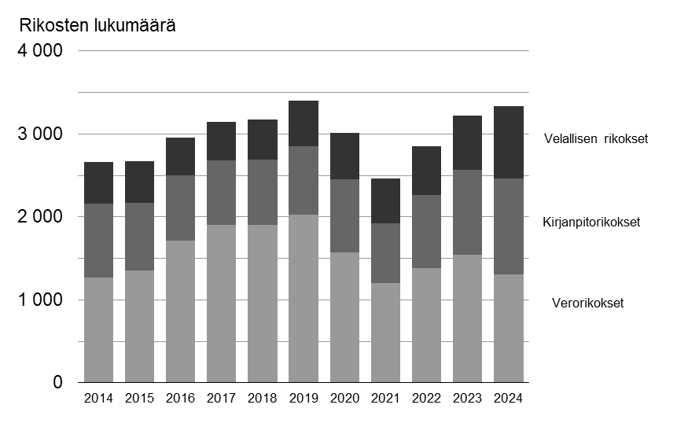

Vero-, kirjanpito- ja velallisen rikokset vähenivät vuosina 2019-2021, mutta niiden määrä on lisääntynyt vuosina 2022-2024.

Ilmi tulevan verorikollisuuden määrät ovat kytköksissä sekä rikosten tosiasiallisessa esiintyvyydessä tapahtuviin muutoksiin että viranomaisvalvonnan aktiivisuuteen. Viranomaisten tietoon tulleiden verorikosten määrä ja muutokset mukailevat normaalisti Verohallinnon tekemien rikosilmoitusten määrää, sillä huomattava osa verorikoksista tulee poliisin tietoon Verohallinnon kautta. Verorikosten kokonaismäärään vaikuttaa niin ikään Tullin ja Rajavartiolaitoksen tutkimien rikosten määrä.

Viranomaisen tarkastustoiminta vaikuttanee kuitenkin havaittujen verorikosten määriin. Tarkastustoiminnan painopisteiden vaihtelu voi heijastua verorikoksista epäiltyjen määriin, etenkin mikäli tutkinnoissa priorisoidaan suuria, korkean rikoshyödyn tapauksia. Kuten verorikollisuus, myös ilmi tuleva kirjanpitorikollisuus on suurelta osin yhteydessä kontrollin tasoon, sillä kirjanpitorikokset paljastuvat yleensä vero- tai velallisen rikoksen yhteydessä. Rikoksista huomattava osa tulee ilmi verotarkastuksissa.

**Taulukko 1** Verohallinnossa tehdyt rikosilmoitukset vuosina 2015–2024

|  | *2015* | *2016* | *2017* | *2018* | *2019* | *2020* | *2021* | *2022* | *2023* | *2024* |
| --- | --- | --- | --- | --- | --- | --- | --- | --- | --- | --- |
| Rikosilmoitukset | 550 | 796 | 1001 | 740 | 920 | 930 | 960 | 1093 | 1210 | 1149 |
| Lainkohdat | 957 | 1175 | 1414 | 978 | 1147 | 1238 | 1165 | 1359 | 1500 | 1364 |

*Lähde:* Verohallinto (Verohallinto 2016; 2019; 2020; 2024;2025)

Verohallinnon tekemien rikosilmoitusten määrä kasvoi vuosien 2015–2017 välisenä aikana sekä rikosilmoitusten että lainkohtien määrällä laskien (taulukko 1). Vuonna 2018 rikosilmoitusten määrä laski selvästi, mutta vuodesta 2019 eteenpäin sekä rikosilmoitusten että rikosilmoitusten lainkohtien määrä on noussut taas huomattavasti. Huomionarvoista on, että törkeiden tekomuotojen osuus kaikista viranomaisten tietoon tulleista verorikoksista on kasvanut tasaisesti vuodesta 2019. Törkeiden tekomuotojen osuus oli vuonna 2024 noin puolet kaikista verorikoksista, kun vastaava osuus oli vielä vuonna 2019 alle kolmannes. Tämä muutos onkin todennäköisesti seurausta viranomaisten tarkastustoiminnan suunnitelmallisesta painottumisesta vakavan talousrikollisuuden ennaltaehkäisyyn ja torjuntaan, joka voidaan todeta myös törkeiden tekomuotojen osuudesta verohallinnon tekemissä rikosilmoituksissa.

Velallisten rikosten vuotuisen määrän vaihtelu on pitkään ollut kytköksissä konkurssien vaihteluun. Konkurssin yhteydessä kirjattujen velallisrikosten osuus kaikista velallisten rikoksista on ollut viime vuosina laskusuuntaista, mutta vuonna 2024 havaittiin jälleen muutaman prosenttiyksikön kasvua nykyisen osuuden ollessa noin yhdeksän prosenttia velallisen rikoksista. Konkurssien yhteydessä kirjattujen velallisten rikosten määrä ei näyttäisi kuitenkaan seuraavan täysin kaikkien vireillä olleiden konkurssien määrää. Vaikka vuosina 2023–2024 konkurssien määrä on noussut Suomessa kymmenvuotiskauden huippuunsa, konkurssin yhteydessä tehtyjen velallisrikosten määrä jää vielä yli 15 prosenttiyksikön päähän kuluneen kymmenen vuoden korkeimmista rikosluvuista. (Tilastokeskus 2025a; Tilastokeskus 2025b.)

Arvioiden mukaan pääosa talousrikollisuudesta jää viranomaisilta piiloon. Yritysten on kansainvälisesti katsottu ilmoittavan poliisille keskimäärin alle kymmenyksen havaitsemistaan yritykseen kohdistuvista talousrikoksista (Gottschalk & Tcherni-Buzzeo 2017; ks. myös Salmi, Lehti & Keinänen 2011). On myös huomioitava, että merkittävä osa rikoksista jää yleensä paljastumatta ja yritykseen kohdistuvat talousrikokset havaitaankin usein sattumalta (Gottschalk & Tcherni-Buzzeo 2017). Koska rikostyyppi ja rikosvahingon laajuus vaikuttaa rikosten paljastumiseen ja ilmoitusalttiuteen, viranomaisten tietoon tulleiden talousrikosvahinkojen osuus kaikista talousrikoksilla aiheutetuista vahingoista on kuitenkin luultavasti suurempi kuin tietoon tulleiden tekojen osuus kaikista teoista.

Kaiken kaikkiaan piilorikollisuuden laajuudesta talousrikollisuudessa (sen enempää kuin kontrollitoimien vaikutuksesta piilorikollisuuteen) ei Suomessa ole toistaiseksi tehty luotettavia selvityksiä. Viranomaisten tilastoiman talousrikollisuuden perusteella ei siten voi tehdä kovin luotettavia päätelmiä kokonaistalousrikollisuuden kehityksestä. On mahdollista, että talousrikollisuuden määrälliseen kehitykseen vaikuttavat ensisijaisesti viranomaiskontrollin kohdentuminen sekä tutkintaan ja valvontaan kohdistettavat resurssit. Toisaalta, vaikka viranomaisten tietoon tulleiden rikosten määrällinen kehitys ei kuvaisi kokonaisrikollisuuden tasoa, vaikuttaa tilastoitu rikollisuus joka tapauksessa viranomaisten toimintaympäristöön ja resurssien käyttöön.

*Arvopaperimarkkinarikokset*

Viranomaisten kirjaamien arvopaperimarkkinarikosten määrä on perinteisesti ollut hyvin vähäinen. Viimeisen kymmenen vuoden aikana rikosepäilyjä on ollut keskimäärin seitsemän kappaletta vuosittain. Vuonna 2024 viranomaiset kirjasivat kuitenkin poikkeukselliset 19 rikosepäilyä. Kasvu johtui lähes täysin sisäpiirintiedon väärinkäytöistä, jotka kattoivat yli 60 prosenttia koko vuoden arvopaperimarkkinarikoksista (Tilastokeskus 2025b). Seuraavassa tarkastelun kohteena on viranomaisten kirjaamien rikosepäilyjen sijasta Finanssivalvonnan käsittelemien valvontatapauksien määriä.

Vuosina 2015–2024 Finanssivalvonta on käsitellyt kaikkiaan 1 379 valvontatapausta ja poliisille tehtiin tutkintapyyntö 65 tapauksesta (taulukko 2). Pääosa viime vuosina käsitellyistä valvontatapauksista on koskenut sisäpiiritiedon väärinkäyttöä ja markkinoiden manipulaatioepäilyjä. Vuonna 2024 tutkittuja ja päättyneitä tapauksia oli 207, joista noin kolme neljännestä koski sisäpiiritiedon väärinkäyttöä. Finanssivalvonnan käsittelemien valvontatapausten määrä on muodostanut viime vuosina seurantajakson selkeän huipun, lukumäärän noustessa edelleen vuonna 2024 korkeammalle kuin kertaakaan kymmeneen vuoteen (Finanssivalvonta 2025a).

Vuonna 2024 tehtiin jopa 18 tutkintapyyntöä poliisille sekä määrättiin yhdeksän seuraamusmaksua. Julkisia varoituksia tai rikemaksuja ei annettu. Seuraamusmaksut koskivat muun muassa johtohenkilöiden liiketoimi-ilmoitusten viivästymisiä, laiminlyöntejä rahanpesun estämisen sääntelyn noudattamisessa sekä liiketoimikiellon rikkomista. (Finanssivalvonta 2025b).

**Taulukko 2** Finanssivalvonnan käsittelemät arvopaperimarkkinoiden kaupankäyntiin ja tiedonantovelvollisuuteen liittyvät valvontatapaukset 2015–2024

|  | *2015* | *2016* | *2017* | *2018* | *2019* | *2020* | *2021* | *2022* | *2023* | *2024* |
| --- | --- | --- | --- | --- | --- | --- | --- | --- | --- | --- |
| Sisäpiiritiedon väärinkäyttö | 57 | 48 | 58 | 71 | 83 | 105 | 65 | 88 | 145 | 156 |
| Markkinoiden | 40 | 31 | 24 | 23 | 50 | 39 | 41 | 21 | 31 | 37 |
| manipulointi |  |  |  |  |  |  |  |  |  |  |
| Tiedonanto- | 24 | 23 | 12 | 12 | 15 | 9 | 6 | 13 | 11 | 4 |
| velvollisuus |  |  |  |  |  |  |  |  |  |  |
| Muu | 6 | 2 | 1 | 2 | 2 | 2 | 3 | 5 | 4 | 10 |
| Yhteensä | 127 | 104 | 95 | 108 | 150 | 155 | 115 | 127 | 191 | 207 |
| Tutkintapyyntö | 5 | 2 | 6 | 5 | 2 | 6 | 8 | 5 | 8 | 18 |
| poliisille |  |  |  |  |  |  |  |  |  |  |
| Julkinen varoitus | - | 2 | 5 | 3 | 1 | 1 | 1 | 2 | 1 | - |
| Rikemaksu | 19 | 2 | 3 | - | - | 1 | - | 2 | 1 | - |
| Seuraamusmaksu | - | 3 | 4 | 3 | 5 | 2 | 2 | 3 | - | 9 |

*Lähde:* Finanssivalvonta: sanktiot, tutkintapyynnöt ja arvopaperimarkkinoiden tutkintatapaukset (Finanssivalvonta 2025a).

Rahanpesurikokset (RL 32:6–10)

Rikoslain mukaan rahanpesusta tulee rangaista sitä, joka ottaa vastaan tai muutoin puuttuu rikoksella hankittuun omaisuuteen, rikoksen tuottamaan hyötyyn tai niiden tilalle tulleeseen omaisuuteen tarkoituksenaan peittää tai hävittää sen laiton alkuperä tai avustaa rikoksentekijää välttämään rikoksensa oikeudelliset seuraamukset. Myös rahanpesun avustaminen ja yritys, mukaan lukien omaisuuden hallussapito, ovat rangaistavia. Vuonna 2017 tuli voimaan uudistunut laki rahanpesun ja terrorismin rahoittamisen estämisestä (444/2017), jonka mukaan eräiden yhteisöjen ja elinkeinonharjoittajien, muun muassa luottolaitosten ja rahapeliyhteisöjen, on laissa mainituissa tapauksissa tehtävä ilmoitus Rahanpesun selvittelykeskukselle. Vuodesta 2019 alkaen ilmoitusvelvollisuus on koskenut myös virtuaalivaluuttapalvelujen tarjoajia.

Viranomaisten tietoon tuli hieman vajaa 1500 rahanpesurikosta vuoden 2024 aikana, määrän noustua edellisestä vuodesta. (Tilastokeskus 2025b). Viime vuosien tapausmäärien kasvu voi selittyä paitsi yritysten talousvaikeuksilla ja konkurssien lisääntymisellä, myös erinäisillä poliisin tietoon tulleilla suuremmilla rikoskokonaisuuksilla ja viranomaistahojen toimenpiteillä. Muun muassa Keskusrikospoliisissa ilmoitusten käsittelyä ja henkilöstöresursseja on tehostanut vuoden 2023 loppupuolelta alkaen EU:n rahoittaman sisäisen turvallisuuden rahaston (ISF) rahoitus pakotteiden kiertämisen paljastamiseen keskittyvälle toiminnolle (Keskusrikospoliisi 2025). Sisä-Suomen poliisilaitokselle vuonna 2024 perustettu tietoverkkoavusteisten rikosten torjunnan yksikkö on hyvin todennäköisesti myös tehostanut TVA-rikosten havaitsemista ja torjuntaa. Näiden lisäksi kryptovaluuttapalveluiden ilmoittamisvelvollisuutta tiukentava EU:n niin kutsutun MiCA-asetuksen (2023/1114) voimaan astuminen tulee todennäköisesti näkymään rahanpesurikoksissa tulevina vuosina.

Yleisimpiä rahanpesurikosten esirikoksia ovat olleet petokset; erityisesti vuonna 2024 korostuivat valesivuja, huijauslinkkejä ja huijaussoittoja hyödyntäneet tietojenkalastelurikokset, jotka kattoivat yli puolet Rahanpesun selvittelykeskukselle ilmoitetuista petoksista. Huomattava osa kaikesta ilmi tulleesta rahanpesurikollisuudesta liittyykin myös laajemmin petoksiin: törkeät petokset ja maksuvälinepetokset kattavat liki puolet tapauksista, joihin Rahanpesun selvittelykeskuksen tietoja luovutettiin vuonna 2024. Osuus on kasvanut selkeästi viime vuosina. (Keskusrikospoliisi 2025.)

**Taulukko 3** Epäilyttäviä liiketoimia koskevat ilmoitukset (tuhatta) ja tapahtumien määrä (miljoonaa) 2015–2024

|  | *2015* | *2016* | *2017* | *2018* | *2019* | *2020* | *2021** | *2022* | *2023* | *2024* |
| --- | --- | --- | --- | --- | --- | --- | --- | --- | --- | --- |
| Ilmoitukset (tuhatta) | 37,7 | 31,2 | 48,3 | 39,2 | 66,5 | 62,04 | 3692,6 | 230,2 | 347,0 | 53,5 |
| Tapahtumien määrä (milj.) | 0,9 | 1,0 | 1,6 | 1,3 | 1,3 | 2,4 | 6,9 | 1,6 | 1,9 | 1,0 |

* Vuoden 2021 poikkeuksellinen piikki johtui virtuaalivaluuttapalvelujen tarjoajien merkittävistä ilmoitusmääristä, jotka olivat seurausta v. 2019 lopussa voimaan astuneesta ilmoitusvelvollisuudesta. Muiden kuin virtuaalivaluuttapalvelujen tarjoajien toimesta ilmoituksia tehtiin 60 852 ja tapahtumia oli noin 1,9 miljoonaa.

*Lähteet:* Keskusrikospoliisi, Rahanpesun selvittelykeskus (Keskusrikospoliisi 2015; 2017; 2019; 2020; 2021; 2022a; 2023; 2025)

Rahanpesun selvittelykeskukselle tehtiin vuonna 2024 yhteensä 53 482 ilmoitusta epäilyttävistä liiketoimista tai terrorismin rahoittamisesta (taulukko 3). Kyseessä on selkeä lasku edeltävistä kolmesta vuodesta, jolloin erityisesti maksujenvälitystä tarjoavat ilmoitusvelvolliset nostivat ilmoitusmäärät poikkeuksellisen korkealle. Ilmoitusmäärän lasku johtuikin Rahanpesun selvittelykeskuksen (2025) mukaan etenkin maksunvälittäjien ilmoituksista. Samanaikaisesti erityisesti pankit kasvattivat ilmoitusmääriään entisestään vuonna 2024. Tietyiltä osin ilmoitusmääriin vaikutti myös yksittäisen huolehtimisvelvoitteen piirissä olevan viranomaisen ilmoitusaktiivisuuden lisääntyminen.

Rahanpesurekisteriin kirjattiin vuoden aikana lähes miljoona tapahtumaa (joista noin 26 000 virtuaalivaluuttatransaktioita), joiden yhteisarvo oli noin 3,1 miljardia euroa (virtuaalivaluuttatransaktioiden osuus noin 36 miljoonaa euroa). Suomesta ulkomaille kohdistuneissa ei-virtuaalivarojen transaktioissa merkittävimpiä kohdemaita olivat Liettua ja Espanja, kun ulkomailta Suomeen kohdistuneiden vastaavien transaktioiden lähtömaita olivat erityisesti Montenegro ja Venäjä. Lähtö- tai kohdemaa, tai molemmat, olivat valtaosassa virtuaalivaluuttatransaktioita tunnistamattomia. Tehdyistä ilmoituksista käynnistettiin vuoden 2024 aikana 1 347 selvittelykokonaisuutta, joista 1 301 liittyi rahanpesun selvittelyyn ja 46 mahdolliseen terrorismin rahoittamiseen. Avatuista selvittelykokonaisuuksista 23 perusteella kirjattiin uusi rikosilmoitus. Tiedonluovutuksia tehtiin kaikkiaan 1 651. (Keskusrikospoliisi 2025.)

## 7.2 Talousrikosten piirteitä

Talousrikosten katsotaan usein muodostavan oman rikoskäyttäytymisen kategorian, joka poikkeaa ominaispiirteiltään muusta rikollisuudesta (ks. laajemmin Kivivuori ym. 2018). Tutkimuskirjallisuudessa talousrikollisuudesta käytetäänkin toisinaan myös termiä valkokaulusrikollisuus. Terminologia alleviivaa käsitystä, että talousrikoksiin syyllistyneet ovat keskimäärin paremmin toimeentulevia kuin muihin rikoksiin, kuten pahoinpitely- ja varkausrikoksiin syyllistyneet henkilöt. Seuraavassa tarkastellaan talousrikoksiin syylliseksi epäiltyjen henkilöiden ikä- ja sukupuolirakennetta sekä sosioekonomista asemaa poliisin tietoon tulleen rikollisuuden osalta. Tarkastelun kohteena ovat vero- (RL 29:1–4), kirjanpito- (RL 30:9–10) ja velallisen rikokset (RL 39:1–6).

*Ikä ja sukupuoli.* Vero-, kirjanpito- ja velallisen rikoksiin syyllistyneiden henkilöiden ikärakenne poikkeaa olennaisesti niin kutsuttuihin massarikoksiin syyllistyneiden ikärakenteesta. Esimerkiksi pahoinpitelyrikoksissa ja varkausrikoksissa ikärakenne on painottunut voimakkaasti nuorempiin ikäryhmiin (ks. luku 5), kun taas talousrikoksissa vanhemmat ikäryhmät ovat yliedustettuna (kuvio 2). Vuonna 2024 rikostaso oli korkein 40–49-vuotiailla, joiden osalta epäiltyjä oli 15 henkilöä ikäryhmän 10 000 henkilöä kohti. Alle 30-vuotiaiden osuus rikoksista epäillyistä oli varkausrikoksissa 42 prosenttia ja pahoinpitelyrikoksissa 48 prosenttia, mutta talousrikoksissa vain 16 prosenttia

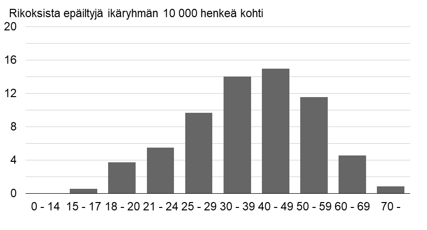

Vero-, kirjanpito- tai velallisen rikoksiin syyllistytään tyypillisesti 30-49-vuotiaana. Alaikäisten rikollisuus on kyseisessä rikostyypissä erittäin harvinaista.

**Kuvio 2** Vero-, kirjanpito- tai velallisen rikoksista epäillyt ikäryhmän 10 000 henkilöä kohden vuonna 2024. *Lähteet:* Tilastokeskus, rikos- ja pakkokeinotilasto (Tilastokeskus 2025b); Tilastokeskus, väestörakenne (Tilastokeskus 2025d).

Vero-, kirjanpito- ja velallisen rikoksista epäiltyjen sukupuolirakenne vastaa kuitenkin ns. massarikollisuudessa esiintyvää sukupuolirakennetta. Vuonna 2024 edellä mainituista talousrikoksista epäillyistä 80 prosenttia oli miehiä, kun osuus pahoinpitelyrikoksissa oli 79 prosenttia ja varkausrikoksissa 72 prosenttia. Kuten massarikoksissa, myös talousrikoksissa miehet ovat siis selkeästi yliedustettuna rikoksista epäillyistä.

*Sosioekonominen asema.* Vero-, kirjanpito- ja velallisen rikoksiin syyllistyneiden henkilöiden sosioekonomisen aseman rakenne poikkeaa massarikoksiin syyllistyneiden sosioekonomisesta asemasta joiltakin osin. Esimerkiksi varkaus- ja petosrikoksissa korostuvat opiskelijat ja työvoiman ulkopuolella olevat (ks. luku 5), mainituissa talousrikoksissa puolestaan yrittäjät sekä muut tarkemmin määrittämättömät sosioekonomiset ryhmät (taulukko 4).

| Sosioekonominen asema | Osuus epäillyistä (%) | Rikosten määrä / 10000 henk. |
| --- | --- | --- |
| Ylemmät toimihenkilöt | 5,8 | 1,8 |
| Alemmat toimihenkilöt | 8,6 | 2,2 |
| Työntekijät | 12,6 | 4,2 |
| Yrittäjät | 35,9 | 29,0 |
| Opiskelijat | 3,0 | 2,1 |
| Eläkeläiset (60- v.) | 6,1 | 1,3 |
| Eläkeläiset (alle 60 v.) | 2,6 | 7,3 |
| Muut (pitkäaikaistyöttömät, asevelvolliset, yms.) | 9,4 | 7,2 |
| Tuntematon | 16,0 | - |

*Lähteet:* Tilastokeskus, rikos- ja pakkokeinotilasto (Tilastokeskus 2025b); Tilastokeskus, työssäkäynti (Tilastokeskus 2025c). Sosioekonomista asemaa kuvaavat väestötiedot ovat vuodelta 2023.

Vero-, kirjanpito- ja velallisen rikoksissa väestöön suhteutettu rikostaso oli selkeästi korkein yrittäjillä (29,0 rikosta 10 000 henkilöä kohti). Huomionarvoinen on myös väestöön suhteutettu rikostaso muut-ryhmään kuuluvilla (7,2), joka sisältää muun muassa pitkäaikaistyöttömät, sekä alle 60-vuotiailla eläkeläisillä (7,3). Yrittäjien korkeaa talousrikostasoa selittänee yrittäjyyteen (elinkeinotoimintaan) liittyvä tilaisuusrakenne. Yrittäjällä ei aina ole työnantajan kaltaista, aktiivisesti toimintaa ohjaavaa tahoa, vaan arkipäivän toiminta voi tarjota herkemmin sopivan kohteen, valvomattoman tilan sekä toisaalta motivaation erilaisten verorikosten tekemiseen (ks. Cohen & Felson 1979). Merkittävää on kuitenkin se, että myös talousrikoksissa, kuten muissakin rikoslajeissa, toimihenkilöiden rikostaso on varsin matala. Tasoero muihin sosioekonomisiin ryhmiin nähden oli kuitenkin tasaisempi kuin esimerkiksi varkausrikoksissa, joissa ero toimihenkilöiden ja korkeimpien rikostasojen ryhmien välillä oli monikymmenkertainen. Rikoksista epäiltyjen rikostason tarkastelussa ryhmän 10 000 henkilöä kohden tulee kuitenkin huomioida talousrikosten viime vuosina pidentyneet tutkinta-ajat, joka vaikuttanee myös epäiltyjen määrän mahdollisiin muutoksiin (Kietäväinen ym. 2022).

*Tulot.* Taulukossa 5 kysymystä epäiltyjen sosioekonomisesta rakenteesta eri rikoslajien osalta on tarkasteltu tulokymmenyksittäin. Tarkastelun perusteella havaitaan, että varakkaimpiin tuloluokkiin kuuluvien epäiltyjen osuus on huomattavasti korkeampi talousrikoksissa kuin pahoinpitelyissä, petoksissa tai varkausrikoksissa. Vuonna 2024 vero-, kirjanpito- tai velallisen rikoksista epäillyistä 7 prosenttia kuului korkeimpaan tulokymmenykseen, kun osuus pahoinpitelyrikoksissa oli neljä prosenttia, petoksissa kaksi prosenttia ja varkausrikoksissa prosentin. Toisaalta voidaan kuitenkin havaita, että myös talousrikoksissa vähävaraisin tulokymmenys on yliedustettuna rikoksista epäillyistä: mainituissa talousrikoksissa osuus epäillyistä oli 21 prosenttia, kun osuudet muissa rikostyypeissä vaihtelivat 24 ja 33 prosentin välillä.

**Taulukko 5** Eräistä rikoksista epäillyt henkilöt tulokymmenyksen mukaan vuonna 2024

| Tulokymmenys | Osuus epäillyistä* (%) |  |  |  |  |
| --- | --- | --- | --- | --- | --- |
|  | Vero-, kirjanpito- ja velallisen rikokset | Pahoin-pitelyt | Petokset |  | Varkaus-rikokset |
| I (vähävaraisin 10 %) | 21 | 33 | 24 | 31 |  |
| II | 14 | 20 | 28 | 32 |  |
| III | 7 | 11 | 13 | 16 |  |
| IV | 7 | 7 | 8 | 7 |  |
| V | 10 | 4 | 2 | 1 |  |
| VI | 11 | 2 | 7 | 6 |  |
| VII | 8 | 7 | 10 | 4 |  |
| VIII | 7 | 6 | 4 | 2 |  |
| IX | 7 | 6 | 2 | 2 |  |
| X (varakkain 10 %) | 7 | 4 | 2 | 1 |  |

* Osuus on laskettu vain niistä, joiden tulokymmenys voitiin määritellä.  
*Lähde*: Tilastokeskus, rikos- ja pakkokeinotilasto (Tilastokeskus 2024b)

Kokonaisuutena tarkastellen on selvää, että keskeisistä talousrikoksista epäillyt ovat keskimäärin parempituloisia ja keskimäärin paremmassa sosioekonomisessa asemassa kuin muista rikostyypeistä epäillyt henkilöt. Epäillyt ovat myös pääsääntöisesti vanhempia kuin muissa rikostyypeissä. Toisaalta myös talousrikoksissa, kuten muussa rikollisuudessa, heikommin toimeentulevat ovat yliedustettuna epäiltyjen joukossa. Havainto on täysin linjassa kansainvälisen tutkimusnäytön kanssa, jonka mukaan talousrikoksiin syyllistyneet ovat keskimäärin parempiosaisia kuin muissa rikostyypeissä, mutta talousrikollisuudella on myös yhtymäkohtia niin kutsuttuun massarikollisuuteen (ks. Kivivuori ym. 2018; myös Apel & Paternoster 2009).

Monimutkaisissa talousrikoksissa rikoksen tutkintaan käytettävä aika voi olla hyvinkin pitkä. Esimerkiksi osa verorikoksista on luonteeltaan rajat ylittävää rikollisuutta, joissa voi olla kymmeniä, ellei satoja asianosaisia. Tässä julkaisussa selvitysaste kuvaa *samana tilastointivuonna* selvitettyjä rikoksia, mikä on otettava huomioon lukujen tulkinnassa. Tosiasiallisesti rikosten lopullinen selvitysaste on korkeampi.

Vuonna 2024 vero-, kirjanpito- ja velallisen rikoksista 16 prosenttia selvitettiin saman tilastovuoden aikana (Tilastokeskus 2025b). Taso kasvoi pitkään melko tasaisesti vuoteen 2019 saakka, huolimatta rikosten samanaikaisesta lisääntymisestä, jonka jälkeen se on laskenut viidessä vuodessa lähes 30 prosenttiyksikköä huipustaan. Tilastointivuonna kirjattujen ja selvitettyjen (riippumatta alkuperäisestä kirjausvuodesta) rikosten suhde on olennaisesti korkeampi, joskin hieman laskusuuntainen: luku on vaihdellut viime vuosina 63–96 prosentin välillä. Mahdollisia syitä saman tilastovuoden aikana selvitettyjen rikosten määrän laskuun ovat esimerkiksi virtuaalivaluutoista tehtyjen ilmoitusten merkittävä kasvu, identiteettivarkauksien lisääntyminen sekä globaalit, paljon aikaa ja resursseja vaativat rikosvyyhdet erityisesti Venäjän hyökkäyssodan, pakotteiden ja globaalisti epävakaan tilan aikana.

## 7.3 Lähteet

Asetus (EU) 2023/1114. Eurooppalainen kryptovarojen sääntely (MiCA-asetus). https://eur-lex.europa.eu/FI/legal-content/summary/european-crypto-assets-regulation-mica.html

Alvesalo-Kuusi, Anne, Liisa Lähteenmäki, Minna Janhonen, Jussi Tapani & Tuula Räsänen. 2017. *Yhteisövastuu, turvallisuus ja työturvallisuusrikos muuttuvan työelämän ja lainsäädännön käytännöissä*. Helsinki: Työterveyslaitos. http://urn.fi/URN:ISBN 978-952-261-687-6

Apel, Robert & Raymond Paternoster. 2009. “Understanding”Criminogenic” Corporate Culture: What White-Collar Crime Researchers Can Learn from Studies of the Adolescent Employment–Crime Relationship.” Teoksessa *The Criminology of White-Collar Crime*, toimittajat Sally S. Simpson & David Weisburd, 15–33. New York: Springer. https://doi.org/10.1007/978-0-387-09502-8_2.

Cohen, Lawrence E. & Marcus Felson (1979). Social Change and Crime Rate Trends: A Routine Activity Approach. *American Sociological Review* 44: 4, 588–608.

Finanssivalvonta. 2025a. “Sanktiot, tutkintapyynnöt ja arvopaperimarkkinoiden tutkintatapaukset.” Helsinki: Finanssivalvonta. https://www.finanssivalvonta.fi/tilastot/sanktiot-tutkintapyynnot-ja-arvopaperimarkkinoiden-tutkintatapaukset/ (viitattu 23.9.2025).

Finanssivalvonta. 2025b. Tiedotteet ja julkaisut: Lehdistötiedotteet. https://www.finanssivalvonta.fi/tiedotteet-ja-julkaisut/lehdistotiedotteet/2024/ (viitattu 29.9.2025).

Gottschalk, Petter & Maria Tcherni-Buzzeo. 2017. “Reasons for Gaps in Crime Reporting: The Case of White-Collar Criminals Investigated by Private Fraud Examiners in Norway.” *Deviant Behavior* 38(3): 267–281. https://doi.org/10.1080/01639625.2016.1196993

Keskusrikospoliisi. 2015. *Rahanpesun selvittelykeskuksen vuosikertomus 2014*. Vantaa: Keskusrikospoliisi.

Keskusrikospoliisi. 2017. *Rahanpesun selvittelykeskuksen vuosikertomus 2016*. Vantaa: Keskusrikospoliisi.

Keskusrikospoliisi. 2019. *Rahanpesun selvittelykeskuksen vuosikertomus 2018*. Vantaa: Keskusrikospoliisi.

Keskusrikospoliisi. 2020. *Rahanpesun selvittelykeskuksen vuosikertomus 2019*. Vantaa: Keskusrikospoliisi.

Keskusrikospoliisi. 2021. *Vuosikertomus. Rahanpesun selvittelykeskus 2020*. Vantaa: Keskusrikospoliisi.

Keskusrikospoliisi. 2022a. *Rahanpesurikokset oikeuskäytännössä – Törkeät rahanpesutuomiot Helsingin hovioikeudessa 2019–6/2022.* Vantaa: Keskusrikospoliisi.

Keskusrikospoliisi. 2022b. *Vuosikertomus. Rahanpesun selvittelykeskus 2021*. Vantaa: Keskusrikospoliisi.

Keskusrikospoliisi. 2023. *Vuosikertomus. Rahanpesun selvittelykeskus 2022*. Vantaa: Keskusrikospoliisi.

Keskusrikospoliisi. 2025. *Vuosikertomus. Rahanpesun selvittelykeskus 2024*. Vantaa: Keskusrikospoliisi.

Kivivuori, Janne, Mikko Aaltonen, Matti Näsi, Karoliina Suonpää & Petri Danielsson. 2018. *Kriminologia – Rikollisuus ja kontrolli muuttuvassa yhteiskunnassa*. Helsinki: Gaudeamus.

Saarikkomäki, Elsa, Martti Lehti & Janne Kivivuori. 2019. *Vähittäiskauppaan ja majoitus- ja ravintola-alaan kohdistuvat rikokset*. Katsauksia 33/2019. Helsinki: Kriminologian ja oikeuspolitiikan instituutti. http://hdl.handle.net/10138/298436.

Salmi, Venla, Martti Lehti & Anssi Keinänen. 2011. *Kauppa ja teollisuus rikosten kohteena*. OPTL:n tutkimuksia 254. http://hdl.handle.net/10138/152422.

SM-2006-02150/Ri-0. “Talousrikollisuuteen liittyvä tutkimus. Sisäasiainministeriön kirje yliopistoille, korkeakouluille ja tutkimuslaitoksille 28.8.2006.”

Suomen kansallinen ympäristörikosseurantatyöryhmä. 2024. *Ympäristörikoskatsaus 2024*. Helsinki: Poliisihallitus.

Tilastokeskus. 2025a. *Konkurssit*. Helsinki: Tilastokeskus. https://stat.fi/tilasto/kony.

Tilastokeskus. 2025b. *Rikos- ja pakkokeinotilasto*. Helsinki: Tilastokeskus. https://stat.fi/til/rpk.

Tilastokeskus. 2025c. *Työssäkäynti*. Helsinki: Tilastokeskus. https://www.stat.fi/til/tyokay.

Tilastokeskus. 2025d. *Väestörakenne*. Helsinki: Tilastokeskus. http://www.stat.fi/til/vaerak.

Verohallinto. 2016. *Harmaa talous, valvontatilastoja 2015*. Helsinki: Verohallinto.

Verohallinto. 2019. “Harmaa talous ja talousrikollisuus, verotus.” [https://www.vero.fi/harmaa-talous-rikollisuus/torjunta/verotus](https://www.vero.fi/harmaa-talous-rikollisuus/torjunta/verotus%20) (viitattu 28.8.2019).

Verohallinto. 2020. “Harmaa talous ja talousrikollisuus, verotus.” [https://www.vero.fi/harmaa-talous-rikollisuus/torjunta/verotus](https://www.vero.fi/harmaa-talous-rikollisuus/torjunta/verotus%20) (viitattu 4.6.2020).

Verohallinto. 2024. “Harmaa talous ja talousrikollisuus, verotus.” https://www.vero.fi/harmaa-talous-rikollisuus/torjunta/torjuntatilastot/verotus (viitattu 26.9.2025).